# PRAMS Data Analysis R Notebook

Amber Tran

Nov 2024

```r
library(dplyr)
library(pROC)
```

```r
library(ggplot2)
```

Analysis 1: Predictive factors for BC Method: logistic regression

```r
dat <- read.csv('/Users/ambertran/Documents/Yale_MS_Health_Informatics/BIS_560/PRAMS_Dataset1_Clean.csv')
head(dat)
```

```
##   X           ID STATE INCOME8 MARRIED MAT_AGE_PU MAT_DEG MAT_RACE_PU HISP_BC
## 1 1 2016AR226004    AR       3       1         20       4           2       2
## 2 2 2016AR226008    AR       3       1         19       3           2       2
## 3 3 2016AR226009    AR       1       1         20       3           2       2
## 4 4 2016AR226014    AR       1       1         26       3           2       2
## 5 5 2016AR226015    AR       2       2         22       3           2       2
## 6 6 2016AR226016    AR      11       1         23       5           2       2
##   PP_INS_TYPE BC_NOW4
## 1           0       1
## 2           0       1
## 3           0       1
## 4           0       0
## 5           0       1
## 6           1       1
```

Visualize birth control usage by state (0 = no, 1 = yes)

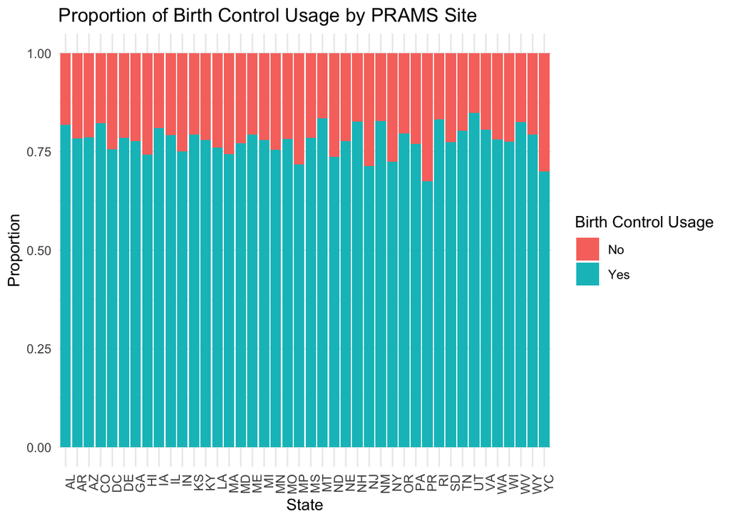

```r
dat_yn <- dat %>%
  mutate(BC_NOW4 = factor(BC_NOW4, levels = c(0, 1), labels = c("No", "Yes")))

ggplot(dat_yn, aes(x = STATE, fill = BC_NOW4)) +
  geom_bar(position = "fill") +
  labs(title = "Proportion of Birth Control Usage by PRAMS Site",
       x = "State",
       y = "Proportion",
       fill = "Birth Control Usage") +
  theme_minimal() +
  theme(axis.text.x = element_text(angle = 90, hjust = 1))
```

Model with state included

```r
# Change STATE to numerical variable
dat <- dat %>%
  mutate(STATE = as.numeric(as.factor(STATE)))
model <- glm("BC_NOW4 ~ STATE + INCOME8 + MARRIED + MAT_AGE_PU + MAT_DEG + MAT_RACE_PU + HISP_BC + PP_INS_TYPE", data = dat, family = binomial(link = "logit"))
summary(model)
```

```
##
## Call:
## glm(formula = "BC_NOW4 ~ STATE + INCOME8 + MARRIED + MAT_AGE_PU + MAT_DEG + MAT_RACE_PU + HISP_BC + PP_INS_TYPE",
##     family = binomial(link = "logit"), data = dat)
##
## Coefficients:
##               Estimate Std. Error z value Pr(>|z|)
## (Intercept)  2.2287571  0.0511841  43.544  < 2e-16 ***
## STATE       -0.0017468  0.0004721  -3.700 0.000216 ***
## INCOME8     -0.0002124  0.0001814  -1.171 0.241677
## MARRIED     -0.1692054  0.0128722 -13.145  < 2e-16 ***
## MAT_AGE_PU  -0.0185216  0.0010666 -17.365  < 2e-16 ***
## MAT_DEG      0.0298235  0.0037754   7.899 2.80e-15 ***
## MAT_RACE_PU -0.0128035  0.0007216 -17.744  < 2e-16 ***
## HISP_BC     -0.1241180  0.0149934  -8.278  < 2e-16 ***
## PP_INS_TYPE  0.0414457  0.0084913   4.881 1.06e-06 ***
## ---
## Signif. codes:  0 '***' 0.001 '**' 0.01 '*' 0.05 '.' 0.1 ' ' 1
##
## (Dispersion parameter for binomial family taken to be 1)
##
##     Null deviance: 208656  on 198108  degrees of freedom
## Residual deviance: 207743  on 198100  degrees of freedom
## AIC: 207761
##
## Number of Fisher Scoring iterations: 4
```

```r
exp(coef(model))
```

```
## (Intercept)       STATE     INCOME8     MARRIED  MAT_AGE_PU     MAT_DEG
##   9.2883149   0.9982548   0.9997877   0.8443354   0.9816489   1.0302727
## MAT_RACE_PU     HISP_BC PP_INS_TYPE
##   0.9872781   0.8832756   1.0423166
```

Model without state included

```r
predictors_reduced <- c("INCOME8", "MARRIED", "MAT_AGE_PU", "MAT_DEG", "MAT_RACE_PU", "HISP_BC", "PP_INS_TYPE")
model_reduced <- glm("BC_NOW4 ~ INCOME8 + MARRIED + MAT_AGE_PU + MAT_DEG + MAT_RACE_PU + HISP_BC + PP_INS_TYPE", data = dat, family = binomial(link = "logit"))
summary(model_reduced)
```

```
##
## Call:
## glm(formula = "BC_NOW4 ~ INCOME8 + MARRIED + MAT_AGE_PU + MAT_DEG + MAT_RACE_PU + HISP_BC + PP_INS_TYPE",
##     family = binomial(link = "logit"), data = dat)
##
## Coefficients:
##               Estimate Std. Error z value Pr(>|z|)
## (Intercept)  2.185e+00  4.977e-02  43.901  < 2e-16 ***
## INCOME8     -6.495e-05  1.769e-04  -0.367    0.714
## MARRIED     -1.685e-01  1.287e-02 -13.093  < 2e-16 ***
## MAT_AGE_PU  -1.857e-02  1.066e-03 -17.416  < 2e-16 ***
## MAT_DEG      2.959e-02  3.775e-03   7.837 4.61e-15 ***
## MAT_RACE_PU -1.303e-02  7.190e-04 -18.129  < 2e-16 ***
## HISP_BC     -1.208e-01  1.497e-02  -8.071 6.95e-16 ***
## PP_INS_TYPE  4.105e-02  8.488e-03   4.837 1.32e-06 ***
## ---
## Signif. codes:  0 '***' 0.001 '**' 0.01 '*' 0.05 '.' 0.1 ' ' 1
##
## (Dispersion parameter for binomial family taken to be 1)
##
##     Null deviance: 208656  on 198108  degrees of freedom
## Residual deviance: 207757  on 198101  degrees of freedom
## AIC: 207773
##
## Number of Fisher Scoring iterations: 4
```

```r
exp(coef(model_reduced))
```

```
## (Intercept)     INCOME8     MARRIED  MAT_AGE_PU     MAT_DEG MAT_RACE_PU
##   8.8883360   0.9999351   0.8449231   0.9815979   1.0300273   0.9870506
##     HISP_BC PP_INS_TYPE
##   0.8861906   1.0419062
```

Comparing both models

```r
anova(model_reduced, model, test = "Chisq")
```

```
## Analysis of Deviance Table
##
## Model 1: BC_NOW4 ~ INCOME8 + MARRIED + MAT_AGE_PU + MAT_DEG + MAT_RACE_PU +
##     HISP_BC + PP_INS_TYPE
## Model 2: BC_NOW4 ~ STATE + INCOME8 + MARRIED + MAT_AGE_PU + MAT_DEG +
##     MAT_RACE_PU + HISP_BC + PP_INS_TYPE
##   Resid. Df Resid. Dev Df Deviance  Pr(>Chi)
## 1    198101     207757
## 2    198100     207743  1   13.696 0.0002149 ***
## ---
## Signif. codes:  0 '***' 0.001 '**' 0.01 '*' 0.05 '.' 0.1 ' ' 1
```

We observe a reduction in the residual deviance by 13.696 with a low p-value < 0.05 (p = 0.0002), suggesting that STATE is a significant predictor of birth control usage after controlling for demographic and insurance factors.

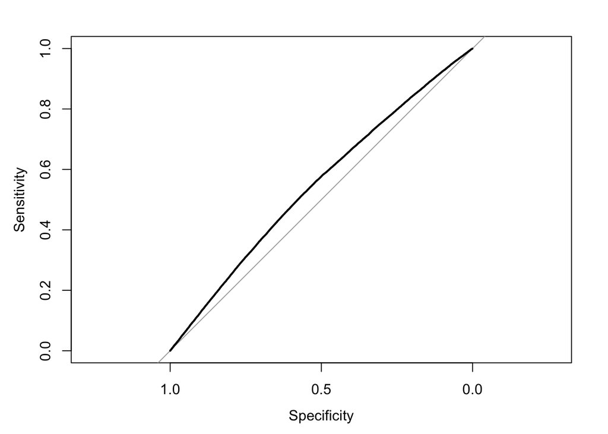

```r
roc_curve <- roc(dat$BC_NOW4, fitted(model))
plot(roc_curve)
```

```r
auc(roc_curve)
```

```
## Area under the curve: 0.5487
```

Our model has a 54.87% chance of correctly classifying birth control or no birth control right now.

Analysis 2: Barriers to adopting birth control Method: chi-square of proportions

```r
dat2 <- read.csv('/Users/ambertran/Documents/Yale_MS_Health_Informatics/BIS_560/PRAMS_Dataset2_Clean.csv')
head(dat2)
```

```
##   X           ID STATE INCOME8 MARRIED MAT_AGE_PU MAT_DEG MAT_RACE_PU HISP_BC
## 1 1 2016AR226014    AR       1       1         26       3           2       2
## 2 2 2016AR226020    AR       1       2         25       3           3       2
## 3 3 2016AR226036    AR       1       2         21       3           3       2
## 4 4 2016AR226082    AR       5       2         26       3           3       2
## 5 5 2016AR226089    AR       4       2         31       3           3       2
## 6 6 2016AR227012    AR       1       2         23       2           2       2
##   PP_INS_TYPE BC_NOW4 BCB_PREG_RAW BCB_PNOW_RAW BCB_TUBE_RAW BCB_WANT_RAW
## 1           0       0            1            1            1            2
## 2           0       0            1            1            1            2
## 3           2       0            1            1            2            1
## 4           3       0            1            1            1            1
## 5           0       0            1            1            1            2
## 6           0       0            1            1            1            1
##   BCB_SIDE_RAW BCB_NSEX_RAW BCB_HUSB_RAW BCB_PAY_RAW
## 1            2            1            1           1
## 2            2            1            1           1
## 3            2            1            1           1
## 4            2            1            1           2
## 5            2            1            1           1
## 6            1            2            1           1
```

Proportion of individuals who said yes, this was a reason by state

```r
# List of reason variables for not using birth control
reason_vars <- c('BCB_PREG_RAW', 'BCB_PNOW_RAW', 'BCB_TUBE_RAW',
                 'BCB_WANT_RAW', 'BCB_SIDE_RAW', 'BCB_NSEX_RAW',
                 'BCB_HUSB_RAW', 'BCB_PAY_RAW')

# Create a function to calculate proportions for each variable
calculate_proportions <- function(dat2, reason_vars) {
  dat2 %>%
    group_by(STATE) %>%
    summarise(across(all_of(reason_vars),
                     ~ sum(. == 2, na.rm = TRUE) / sum(!is.na(.)),
                     .names = "prop_{.col}"))  # Proportions of '2' for each reason
}

# Apply the function
state_proportions <- calculate_proportions(dat2, reason_vars)

# View the result
print(state_proportions)
```

```
## # A tibble: 42 × 9
##    STATE prop_BCB_PREG_RAW prop_BCB_PNOW_RAW prop_BCB_TUBE_RAW prop_BCB_WANT_RAW
##    <chr>             <dbl>             <dbl>             <dbl>             <dbl>
##  1 AL                0.154            0.0357            0.0713             0.461
##  2 AR                0.155            0.0787            0.0861             0.374
##  3 AZ                0.191            0.0106            0.0247             0.403
##  4 CO                0.201            0.0168            0.0314             0.398
##  5 DC                0.155            0.0126            0.0399             0.307
##  6 DE                0.146            0.0154            0.0572             0.380
##  7 GA                0.164            0.0288            0.0432             0.323
##  8 HI                0.196            0.0231            0.0273             0.417
##  9 IA                0.187            0.0568            0.0353             0.459
## 10 IL                0.211            0.0240            0.0317             0.307
## # ℹ 32 more rows
## # ℹ 4 more variables: prop_BCB_SIDE_RAW <dbl>, prop_BCB_NSEX_RAW <dbl>,
## #   prop_BCB_HUSB_RAW <dbl>, prop_BCB_PAY_RAW <dbl>
```

```r
# Sort by the 'prop_BCB_PAY_RAW' column and select the top 10 rows
top_10 <- state_proportions %>%
  select(STATE, prop_BCB_PAY_RAW) %>%
  arrange(desc(prop_BCB_PAY_RAW)) %>%  # Sorting in descending order
  head(10)  # Select the top 10 rows

# View the result
print(top_10)
```

```
## # A tibble: 10 × 2
##    STATE prop_BCB_PAY_RAW
##    <chr>            <dbl>
##  1 PR              0.0665
##  2 IN              0.0489
##  3 MS              0.0437
##  4 WV              0.0435
##  5 UT              0.0431
##  6 WY              0.0423
##  7 KS              0.0421
##  8 GA              0.0418
##  9 IA              0.0384
## 10 MO              0.0384
```

The 10 states/territories with the highest proportion of respondents who checked payment as a barrier to getting postpartum birth control are: Puerto Rico, Indiana, Mississippi, West Virginia, Utah, Wyoming, Kansas, Georgia, Iowa, and Missouri.

```r
# Sort by the 'prop_BCB_PAY_RAW' column and select the bottom 10 rows
bot_10 <- state_proportions %>%
  select(STATE, prop_BCB_PAY_RAW) %>%
  arrange(desc(prop_BCB_PAY_RAW)) %>%  # Sorting in descending order
  tail(10)  # Select the bottom 10 rows

# View the result
print(bot_10)
```

```
## # A tibble: 10 × 2
##    STATE prop_BCB_PAY_RAW
##    <chr>            <dbl>
##  1 CO             0.0176
##  2 PA             0.0150
##  3 YC             0.0149
##  4 IL             0.0147
##  5 MN             0.0129
##  6 HI             0.0128
##  7 DC             0.0105
##  8 RI             0.0103
##  9 WA             0.00950
## 10 MP             0
```

The 10 states/territories with the lowest proportion of respondents who checked payment as a barrier to getting postpartum birth control are: Colorado, Pennsylvania, New York City, Illinois, Minnesota, Hawaii, District of Columbia, Rhode Island, Washington, and Northern Mariana Islands.

```r
# Chi-square test for each reason variable, assuming 1 and 2 as the binary values
chi_square_results <- lapply(reason_vars, function(var) {
  # Create a contingency table: counts of 1 and 2 for each state
  table_data <- table(dat2$STATE, dat2[[var]])

  # Perform chi-square test
  test_result <- chisq.test(table_data)

  # Return the results: statistic, p-value, and degrees of freedom
  return(list(variable = var, statistic = test_result$statistic,
              p_value = test_result$p.value, df = test_result$parameter))
})
# Convert the results into a readable format
chi_square_results_df <- do.call(rbind, lapply(chi_square_results, function(x) data.frame(x)))
print(chi_square_results_df)
```

```
##                variable statistic      p_value df
## X-squared  BCB_PREG_RAW  321.7857 2.988085e-45 41
## X-squared1 BCB_PNOW_RAW  268.0067 4.136228e-35 41
## X-squared2 BCB_TUBE_RAW 2372.2664 0.000000e+00 41
## X-squared3 BCB_WANT_RAW  416.4931 1.206447e-63 41
## X-squared4 BCB_SIDE_RAW  428.5677 5.015524e-66 41
## X-squared5 BCB_NSEX_RAW  374.5247 1.996850e-55 41
## X-squared6 BCB_HUSB_RAW  338.3278 2.018234e-48 41
## X-squared7  BCB_PAY_RAW  272.8909 5.101147e-36 41
```

The chi-square statistics are large and suggest a significant association between the state and the reason for not using birth control. The p-values are extremely small, which confirms that these results are highly statistically significant. The degrees of freedom are consistent with the number of states and binary coded variables.

```r
# Washington, Wisconsin, Delaware, Arkansas, Mississippi
dat3 <- dat2 %>%
  filter(STATE %in% c("WA", "WI", "DE", "AR", "MS"))

# Chi-square test for each reason variable, assuming 1 and 2 as the binary values
chi_square_results <- lapply(reason_vars, function(var) {
  # Create a contingency table: counts of 1 and 2 for each state
  table_data <- table(dat3$STATE, dat3[[var]])

  # Perform chi-square test
  test_result <- chisq.test(table_data)

  # Return the results: statistic, p-value, and degrees of freedom
  return(list(variable = var, statistic = test_result$statistic,
              p_value = test_result$p.value, df = test_result$parameter))
})

# Convert the results into a readable format
chi_square_results_df <- do.call(rbind, lapply(chi_square_results, function(x) data.frame(x)))
print(chi_square_results_df)
```

```
##                variable statistic      p_value df
## X-squared  BCB_PREG_RAW  15.34580 4.035218e-03  4
## X-squared1 BCB_PNOW_RAW  86.33108 7.916382e-18  4
## X-squared2 BCB_TUBE_RAW  30.49584 3.878908e-06  4
## X-squared3 BCB_WANT_RAW  25.17888 4.631018e-05  4
## X-squared4 BCB_SIDE_RAW  16.48701 2.430681e-03  4
## X-squared5 BCB_NSEX_RAW  33.39310 9.923616e-07  4
## X-squared6 BCB_HUSB_RAW  11.55824 2.095724e-02  4
## X-squared7  BCB_PAY_RAW  31.47400 2.450104e-06  4
```

5 States of Interest: Proportions and Frequencies

```r
calculate_proportions <- function(dat3, reason_vars) {
  dat3 %>%
    group_by(STATE) %>%
    summarise(
       total_rows = n(),  # Total number of rows for each state
       across(all_of(reason_vars),
                     list(
                       count_1 = ~ sum(. == 1, na.rm = TRUE), # 1 = no, not checked as a reason
                       count_2 = ~ sum(. == 2, na.rm = TRUE), # 2 = yes, checked as a reason
                       freq_1 = ~ sum(. == 1, na.rm = TRUE) / sum(!is.na(.)),
                       freq_2 = ~ sum(. == 2, na.rm = TRUE) / sum(!is.na(.))
                     ),
                     .names = "{.col}_{.fn}"))
}

# Apply the function
five_states <- calculate_proportions(dat3, reason_vars)

# View the result
print(five_states)
```

```
## # A tibble: 5 × 34
##   STATE total_rows BCB_PREG_RAW_count_1 BCB_PREG_RAW_count_2 BCB_PREG_RAW_freq_1
##   <chr>      <int>                <int>                <int>               <dbl>
## 1 AR           813                  687                  126               0.845
## 2 DE          1102                  941                  161               0.854
## 3 MS           801                  661                  140               0.825
## 4 WA          1473                 1195                  278               0.811
## 5 WI          1452                 1166                  286               0.803
## # ℹ 29 more variables: BCB_PREG_RAW_freq_2 <dbl>, BCB_PNOW_RAW_count_1 <int>,
## #   BCB_PNOW_RAW_count_2 <int>, BCB_PNOW_RAW_freq_1 <dbl>,
## #   BCB_PNOW_RAW_freq_2 <dbl>, BCB_TUBE_RAW_count_1 <int>,
## #   BCB_TUBE_RAW_count_2 <int>, BCB_TUBE_RAW_freq_1 <dbl>,
## #   BCB_TUBE_RAW_freq_2 <dbl>, BCB_WANT_RAW_count_1 <int>,
## #   BCB_WANT_RAW_count_2 <int>, BCB_WANT_RAW_freq_1 <dbl>,
## #   BCB_WANT_RAW_freq_2 <dbl>, BCB_SIDE_RAW_count_1 <int>, …
```

```r
overall_summary <- dat3 %>%
    summarise(
      STATE = "ALL",  # Label for the overall summary row
      total_rows = n(),  # Total number of rows across all states
      across(all_of(reason_vars),
             list(
               count_1 = ~ sum(. == 1, na.rm = TRUE),
               count_2 = ~ sum(. == 2, na.rm = TRUE),
               freq_1 = ~ sum(. == 1, na.rm = TRUE) / sum(!is.na(.)),
               freq_2 = ~ sum(. == 2, na.rm = TRUE) / sum(!is.na(.))
             ),
             .names = "{.col}_{.fn}")
    )

print(overall_summary)
```

```
##   STATE total_rows BCB_PREG_RAW_count_1 BCB_PREG_RAW_count_2
## 1   ALL       5641                 4650                  991
##   BCB_PREG_RAW_freq_1 BCB_PREG_RAW_freq_2 BCB_PNOW_RAW_count_1
## 1           0.8243219           0.1756781                 5436
##   BCB_PNOW_RAW_count_2 BCB_PNOW_RAW_freq_1 BCB_PNOW_RAW_freq_2
## 1                  205           0.9636589          0.03634107
##   BCB_TUBE_RAW_count_1 BCB_TUBE_RAW_count_2 BCB_TUBE_RAW_freq_1
## 1                 5333                  308           0.9453998
##   BCB_TUBE_RAW_freq_2 BCB_WANT_RAW_count_1 BCB_WANT_RAW_count_2
## 1          0.05460025                 3364                 2277
##   BCB_WANT_RAW_freq_1 BCB_WANT_RAW_freq_2 BCB_SIDE_RAW_count_1
## 1           0.5963482           0.4036518                 3714
##   BCB_SIDE_RAW_count_2 BCB_SIDE_RAW_freq_1 BCB_SIDE_RAW_freq_2
## 1                 1927           0.6583939           0.3416061
##   BCB_NSEX_RAW_count_1 BCB_NSEX_RAW_count_2 BCB_NSEX_RAW_freq_1
## 1                 4062                 1579           0.7200851
##   BCB_NSEX_RAW_freq_2 BCB_HUSB_RAW_count_1 BCB_HUSB_RAW_count_2
## 1           0.2799149                 5039                  602
##   BCB_HUSB_RAW_freq_1 BCB_HUSB_RAW_freq_2 BCB_PAY_RAW_count_1
## 1           0.8932813           0.1067187                5499
##   BCB_PAY_RAW_count_2 BCB_PAY_RAW_freq_1 BCB_PAY_RAW_freq_2
## 1                 142          0.9748272         0.02517284
```